# Practica 2

Diego Isau Barranco Herrera

2025-02-28

# Importación de la base

```r
data <- read.csv('/var/home/diegob/Documents/Computer Science/R code/data_prac_2 1.csv')
data <- subset(data, select = -X)
head(data, 10)
```

```
##    edad      sexo    imc hijos fumador   region         clm
## 1    19  femenino   27.9     0     yes suroeste   16884.924
## 2    18 masculino  33.77     1      no  sureste   1725.5523
## 3    28 masculino     33     3      no  sureste    4449.462
## 4    33 masculino 22.705     0      no noroeste 21984.47061
## 5       masculino  28.88     0      no noroeste   3866.8552
## 6    31  femenino  25.74     0      no  sureste   3756.6216
## 7    46  femenino  33.44     1      no  sureste   8240.5896
## 8    37  femenino  27.74     3      no noroeste   7281.5056
## 9    37 masculino  29.83     2      no  noreste   6406.4107
## 10   60  femenino  25.84     0      no noroeste 28923.13692
```

# Limpieza de la base

1. Vamos a verificar primero la consistencia de los datos en cada columna, en caso de que existan valores diferentes, reemplazamos con `NA` Usamos la función `distinct` para extraer el rango de datos de cada columna e identificar lo que no pertenecen a la base ** ¿Por qué no usar `which(is.na(dataCar), arr.ind = TRUE)`? Por la heterogeneidad de datos, es diferente tener “null” a un NA

```r
data %>% distinct(edad)
```

```
##    edad
## 1    19
## 2    18
## 3    28
## 4    33
## 5
## 6    31
## 7    46
## 8    37
## 9    60
## 10   25
## 11   62
## 12   23
## 13   56
## 14   27
```

[output cut: 36 more lines]

```r
data %>% distinct(sexo)
```

```
##        sexo
## 1  femenino
## 2 masculino
```

```r
data %>% distinct(imc)
```

```
##        imc
## 1     27.9
## 2    33.77
## 3       33
## 4   22.705
## 5    28.88
## 6    25.74
## 7    33.44
## 8    27.74
## 9    29.83
## 10   25.84
## 11   26.22
## 12   26.29
## 13    34.4
## 14   39.82
```

[output cut: 530 more lines]

```r
data %>% distinct(hijos)
```

```
##   hijos
## 1     0
## 2     1
## 3     3
## 4     2
## 5     5
## 6     4
```

```r
data %>% distinct(fumador)
```

```
##   fumador
## 1     yes
## 2      no
```

```r
data %>% distinct(region)
```

```
##     region
## 1 suroeste
## 2  sureste
## 3 noroeste
## 4  noreste
```

```r
data %>% distinct(clm)
```

```
##              clm
## 1      16884.924
## 2      1725.5523
## 3       4449.462
## 4    21984.47061
## 5      3866.8552
## 6      3756.6216
## 7      8240.5896
## 8      7281.5056
## 9      6406.4107
## 10   28923.13692
## 11     2721.3208
## 12    27808.7251
## 13      1826.843
## 14    11090.7178
```

[output cut: 1286 more lines]

Se presentan valores como ““,”$$“,”&&“,”null” Vamos a tomar ventaja de que los datos son de tipo carácter para hacer la sustitución de los valores con NA desde el importe de la base

```r
data <- read.csv('/var/home/diegob/Documents/Computer Science/R code/data_prac_2 1.csv', na.strings = c("", "$$", "&&", "null", stringsAsFactor = FALSE))
data <- data %>% select(-X)
head(data, 10)
```

```
##    edad      sexo    imc hijos fumador   region       clm
## 1    19  femenino 27.900     0     yes suroeste 16884.924
## 2    18 masculino 33.770     1      no  sureste  1725.552
## 3    28 masculino 33.000     3      no  sureste  4449.462
## 4    33 masculino 22.705     0      no noroeste 21984.471
## 5    NA masculino 28.880     0      no noroeste  3866.855
## 6    31  femenino 25.740     0      no  sureste  3756.622
## 7    46  femenino 33.440     1      no  sureste  8240.590
## 8    37  femenino 27.740     3      no noroeste  7281.506
## 9    37 masculino 29.830     2      no  noreste  6406.411
## 10   60  femenino 25.840     0      no noroeste 28923.137
```

Ahora vamos a verificar los tipos de datos

```r
sapply(data, class)
```

```
##        edad        sexo         imc       hijos     fumador      region
##   "integer" "character"   "numeric"   "integer" "character" "character"
##         clm
##   "numeric"
```

Listo, tenemos los tipos de datos adecuados

Verificando cuántos valores faltantes hay

```r
colSums(is.na(data))
```

```
##    edad    sexo     imc   hijos fumador  region     clm
##      72       0      39       0       0       0      41
```

Sólamente nos preocuparemos para las variables numéricas, reemplazándolas por alguna técnica vista en clase

2. Vamos a verificar valores duplicados

```r
data %>% janitor::get_dupes()
```

```
## No variable names specified - using all columns.
```

```
##   edad      sexo   imc hijos fumador   region      clm dupe_count
## 1   19 masculino 30.59     0      no noroeste 1639.563          2
## 2   19 masculino 30.59     0      no noroeste 1639.563          2
```

Existen valores duplicados, sin embargo, las variables disponibles en el base, puede que no sirvan como identificador porque puede haber relaciones uno a muchos, propondría agregar una variable más, por ejemplo un número de póliza, o usando las variables existentes una combinación de imc y clm como columna identificadora

```r
# quitando duplicados
data <- unique(data)
head(data, 10)
```

```
##    edad      sexo    imc hijos fumador   region       clm
## 1    19  femenino 27.900     0     yes suroeste 16884.924
## 2    18 masculino 33.770     1      no  sureste  1725.552
## 3    28 masculino 33.000     3      no  sureste  4449.462
## 4    33 masculino 22.705     0      no noroeste 21984.471
## 5    NA masculino 28.880     0      no noroeste  3866.855
## 6    31  femenino 25.740     0      no  sureste  3756.622
## 7    46  femenino 33.440     1      no  sureste  8240.590
## 8    37  femenino 27.740     3      no noroeste  7281.506
## 9    37 masculino 29.830     2      no  noreste  6406.411
## 10   60  femenino 25.840     0      no noroeste 28923.137
```

3. Reemplazando valores faltantes usando media, mediana, media recortada, moda, interpolación

```r
data_numeric <- data %>% select(where(is.numeric))
head(data_numeric,10)
```

```
##    edad    imc hijos       clm
## 1    19 27.900     0 16884.924
## 2    18 33.770     1  1725.552
## 3    28 33.000     3  4449.462
## 4    33 22.705     0 21984.471
## 5    NA 28.880     0  3866.855
## 6    31 25.740     0  3756.622
## 7    46 33.440     1  8240.590
## 8    37 27.740     3  7281.506
## 9    37 29.830     2  6406.411
## 10   60 25.840     0 28923.137
```

## Reemplazo con media

```r
data_mean <- data.frame(lapply(data_numeric, function (x) ifelse(is.na(x), mean(x, na.rm=TRUE), x)))
summary(data_mean)
```

```
##       edad            imc            hijos            clm
##  Min.   :18.00   Min.   :15.96   Min.   :0.000   Min.   : 1122
##  1st Qu.:27.00   1st Qu.:26.40   1st Qu.:0.000   1st Qu.: 4878
##  Median :39.24   Median :30.59   Median :1.000   Median : 9705
##  Mean   :39.24   Mean   :30.62   Mean   :1.096   Mean   :13287
##  3rd Qu.:51.00   3rd Qu.:34.40   3rd Qu.:2.000   3rd Qu.:16115
##  Max.   :64.00   Max.   :53.13   Max.   :5.000   Max.   :63770
```

## Reemplazando con mediana

```r
data_median <- data.frame(lapply(data_numeric, function (x) ifelse(is.na(x), median(x, na.rm=TRUE), x)))
summary(data_median)
```

```
##       edad            imc            hijos            clm
##  Min.   :18.00   Min.   :15.96   Min.   :0.000   Min.   : 1122
##  1st Qu.:27.00   1st Qu.:26.40   1st Qu.:0.000   1st Qu.: 4878
##  Median :39.00   Median :30.30   Median :1.000   Median : 9382
##  Mean   :39.23   Mean   :30.61   Mean   :1.096   Mean   :13167
##  3rd Qu.:51.00   3rd Qu.:34.40   3rd Qu.:2.000   3rd Qu.:16115
##  Max.   :64.00   Max.   :53.13   Max.   :5.000   Max.   :63770
```

## Reemplazando con media recortada

```r
data_median_cut <- data.frame(lapply(data_numeric, function (x) ifelse(is.na(x), mean(x, na.rm=TRUE, trim = 0.2), x)))
summary(data_median_cut)
```

```
##       edad            imc            hijos            clm
##  Min.   :18.00   Min.   :15.96   Min.   :0.000   Min.   : 1122
##  1st Qu.:27.00   1st Qu.:26.40   1st Qu.:0.000   1st Qu.: 4878
##  Median :39.08   Median :30.41   Median :1.000   Median : 9705
##  Mean   :39.23   Mean   :30.61   Mean   :1.096   Mean   :13183
##  3rd Qu.:51.00   3rd Qu.:34.40   3rd Qu.:2.000   3rd Qu.:16115
##  Max.   :64.00   Max.   :53.13   Max.   :5.000   Max.   :63770
```

## Reemplazando con moda

```r
data_mode <-  data.frame(lapply(data_numeric, function (x) ifelse(is.na(x), mfv(x, na_rm=TRUE, trim = 0.1), x)))
summary(data_mode)
```

```
##       edad            imc            hijos            clm
##  Min.   :18.00   Min.   :15.96   Min.   :0.000   Min.   : 1122
##  1st Qu.:25.00   1st Qu.:26.40   1st Qu.:0.000   1st Qu.: 4762
##  Median :38.00   Median :30.59   Median :1.000   Median : 9305
##  Mean   :38.13   Mean   :30.66   Mean   :1.096   Mean   :13254
##  3rd Qu.:51.00   3rd Qu.:34.40   3rd Qu.:2.000   3rd Qu.:16586
##  Max.   :64.00   Max.   :53.13   Max.   :5.000   Max.   :63770
```

## Reemplazando con interpolación

```r
data_interpol <- data.frame(lapply(data_numeric, function (x) ifelse(is.na(x), na.approx(x, na.rm=T), x)))
summary(data_interpol)
```

```
##       edad            imc            hijos            clm
##  Min.   :18.00   Min.   :15.96   Min.   :0.000   Min.   : 1122
##  1st Qu.:27.00   1st Qu.:26.22   1st Qu.:0.000   1st Qu.: 4796
##  Median :39.00   Median :30.40   Median :1.000   Median : 9411
##  Mean   :39.29   Mean   :30.62   Mean   :1.096   Mean   :13274
##  3rd Qu.:51.00   3rd Qu.:34.58   3rd Qu.:2.000   3rd Qu.:16819
##  Max.   :64.00   Max.   :53.13   Max.   :5.000   Max.   :63770
```

La mediana podría ser candidata como técnica de reemplazo porque no difiere mucho de los datos originales

# Usando la base con interpolación

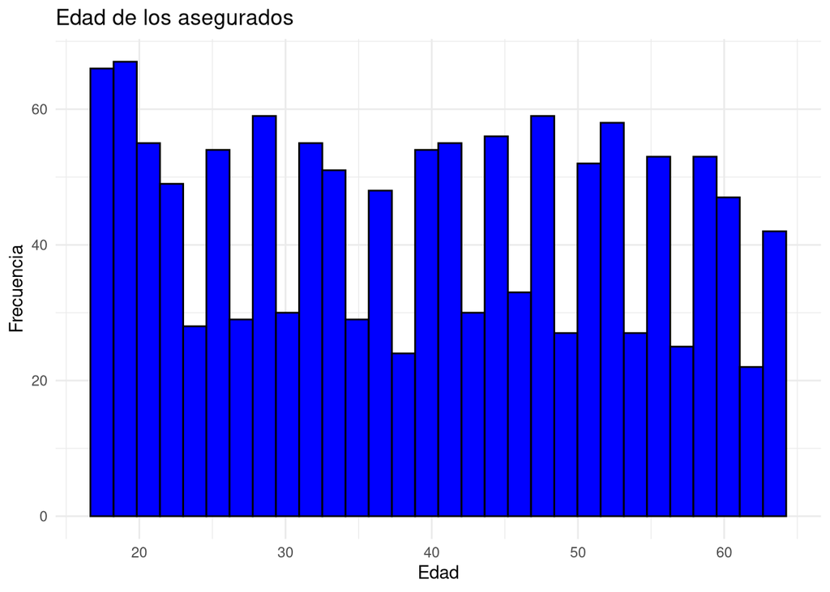

```r
ggplot(data_interpol, aes(x = edad)) +
  geom_histogram(fill = "blue", color = "black") +
  labs(title = "Edad de los asegurados", x="Edad", y="Frecuencia")+
  theme_minimal()
```

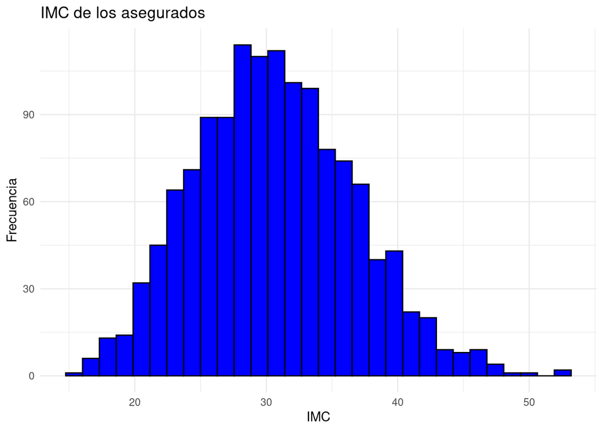

```r
ggplot(data_interpol, aes(x = imc)) +
  geom_histogram(fill = "blue", color = "black") +
  labs(title = "IMC de los asegurados", x="IMC", y="Frecuencia")+
  theme_minimal()
```

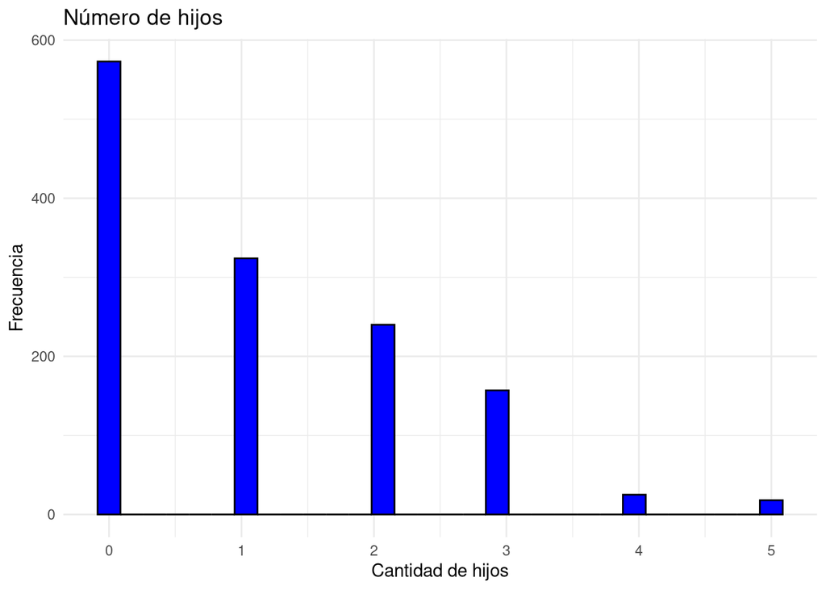

```r
ggplot(data_interpol, aes(x = hijos)) +
  geom_histogram(fill = "blue", color = "black") +
  labs(title = "Número de hijos", x="Cantidad de hijos", y="Frecuencia")+
  theme_minimal()
```

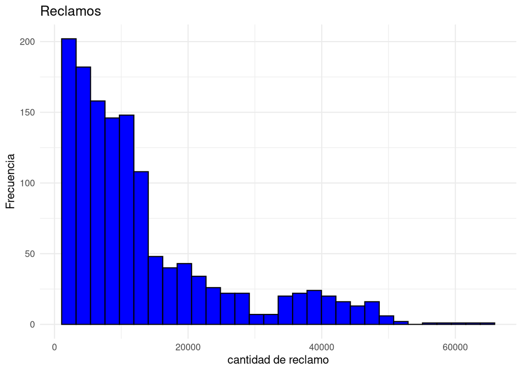

```r
ggplot(data_interpol, aes(x = clm))+
  geom_histogram(fill = "blue", color = "black") +
  labs(title = "Reclamos ", x="cantidad de reclamo", y="Frecuencia")+
  theme_minimal()
```

## media de monto de reclamación por sexo

```r
char_data <- data %>% select(sexo, fumador, region)
data_interpol_all <- cbind(data_interpol, char_data)  # agregando las demás columnas

mean_sex <- data_interpol_all %>%
        group_by(sexo) %>%
        summarise(claim_amount = mean(clm))

mean_sex
```

```
## # A tibble: 2 × 2
##   sexo      claim_amount
##   <chr>            <dbl>
## 1 femenino        12517.
## 2 masculino       14017.
```

## media de monto de reclamación por fumador y sexo

```r
mean_sex_smk <- data_interpol_all %>%
        group_by(fumador, sexo) %>%
        summarise(claim_amount = mean(clm))
mean_sex_smk
```

```
## # A tibble: 4 × 3
## # Groups:   fumador [2]
##   fumador sexo      claim_amount
##   <chr>   <chr>            <dbl>
## 1 no      femenino         8935.
## 2 no      masculino        8206.
## 3 yes     femenino        29556.
## 4 yes     masculino       32874.
```

## Región con mayor monto promedio de reclamación

```r
mean_region <- data_interpol_all %>%
        group_by(region) %>%
        summarise(claim_amount = mean(clm)) %>%
  arrange(desc(claim_amount))

mean_region
```

```
## # A tibble: 4 × 2
##   region   claim_amount
##   <chr>           <dbl>
## 1 sureste        14588.
## 2 noreste        13577.
## 3 noroeste       12418.
## 4 suroeste       12354.
```

## etiquetando registros si el imc es mayor a 30

```r
data_interpol_label <- data_interpol_all %>%
        mutate(clasificacion = ifelse(imc > 30, "obesidad", ""))
head(data_interpol_label,10)
```

```
##    edad    imc hijos       clm      sexo fumador   region clasificacion
## 1    19 27.900     0 16884.924  femenino     yes suroeste
## 2    18 33.770     1  1725.552 masculino      no  sureste      obesidad
## 3    28 33.000     3  4449.462 masculino      no  sureste      obesidad
## 4    33 22.705     0 21984.471 masculino      no noroeste
## 5    32 28.880     0  3866.855 masculino      no noroeste
## 6    31 25.740     0  3756.622  femenino      no  sureste
## 7    46 33.440     1  8240.590  femenino      no  sureste      obesidad
## 8    37 27.740     3  7281.506  femenino      no noroeste
## 9    37 29.830     2  6406.411 masculino      no  noreste
## 10   60 25.840     0 28923.137  femenino      no noroeste
```

## Top 10 personas obesas

```r
obesas <- filter(data_interpol_label, data_interpol_label$clasificacion=='obesidad') %>% arrange(desc(imc))
head(obesas, 10)
```

```
##    edad   imc hijos       clm      sexo fumador   region clasificacion
## 1    18 53.13     0  1163.463 masculino      no  sureste      obesidad
## 2    22 52.58     1 44501.398 masculino     yes  sureste      obesidad
## 3    23 50.38     1  2438.055 masculino      no  sureste      obesidad
## 4    58 49.06     0 11381.325 masculino      no  sureste      obesidad
## 5    52 47.74     1  9748.911 masculino      no  sureste      obesidad
## 6    37 47.60     2 46113.511  femenino     yes suroeste      obesidad
## 7    47 47.52     1  8083.920 masculino      no  sureste      obesidad
## 8    54 47.41     0 63770.428  femenino     yes  sureste      obesidad
## 9    52 46.75     5 12592.534  femenino      no  sureste      obesidad
## 10   54 46.70     2 11538.421  femenino      no suroeste      obesidad
```